# Ford Gobike Data Exploration

By Nafisah Abdulkadir

Introduction

This documents shows a data exploration of February 2019 fordgobike-tripdata

```python
# import all packages and set plots to be embedded inline
import numpy as np
import pandas as pd
import matplotlib.pyplot as plt
import seaborn as sb

%matplotlib inline
```

```python
# load in the dataset into a pandas dataframe
df = pd.read_csv('C:/Users/nafisah.abdulkadir/OneDrive/Udacity Nanaodegree/Final Project/201902-fordgobike-tripdata.csv')
```

```python
# change the data type for start and end time to be datetime
df.start_time = pd.to_datetime(df.start_time)
df.end_time = pd.to_datetime(df.end_time)
```

```python
# convert trip duration to minute
df['duration_min'] = df['duration_sec']/60
df['duration_hour'] = df['duration_sec']/3660
```

```python
# change the data type for bike_share_for_all_trip to be bool
df.bike_share_for_all_trip = (df.bike_share_for_all_trip == 'Yes')
```

```python
# convert datatype of user_type to category
df['user_type'] = df['user_type'].astype('category')
```

# Exploration of Trip Duration

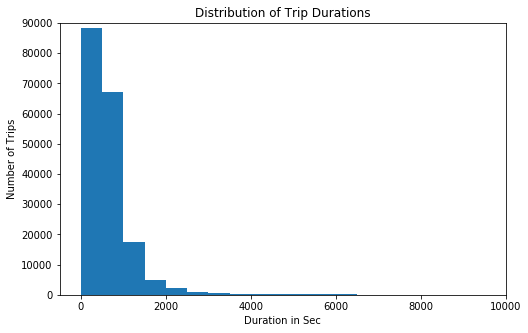

```python
binsize = 500
bins = np.arange(0, df['duration_sec'].max()+binsize, binsize)

plt.figure(figsize=[8, 5])
plt.hist(data = df, x = 'duration_sec', bins = bins)
plt.title('Distribution of Trip Durations')
plt.xlabel('Duration in Sec')
plt.ylabel('Number of Trips')
plt.axis([-500, 10000, 0, 90000])
plt.show()
```

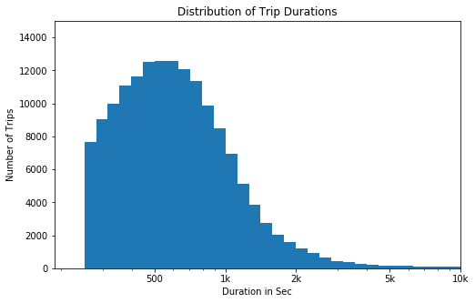

```python
log_binsize = 0.05
bins_log = 10 ** np.arange(2.4, np.log10(df['duration_sec'].max()) + log_binsize, log_binsize)

plt.figure(figsize=[8, 5])
plt.hist(data = df, x = 'duration_sec', bins = bins_log)
plt.title('Distribution of Trip Durations')
plt.xlabel('Duration in Sec')
plt.ylabel('Number of Trips')
plt.xscale('log')
plt.xticks([500, 1e3, 2e3, 5e3, 1e4], [500, '1k', '2k', '5k', '10k'])
plt.axis([0, 10000, 0, 15000])
plt.show()
```

The trip duration peaked at 600seconds aand it centered on values less than 2000 seconds. The no of trips started close to 8000 and peaked slightly above 12000 trips but we began to see a steady decline after this time.

### Trip Duration and Bike Sharing

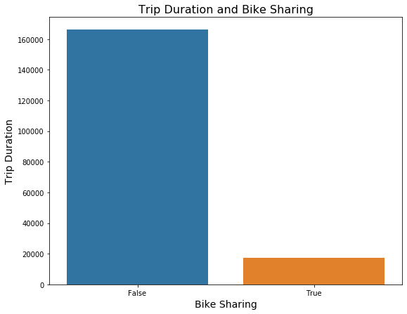

```python
plt.rcParams['figure.figsize'] = 9, 7
sb.countplot(data=df, x='bike_share_for_all_trip');
plt.xlabel('Bike Sharing', fontsize=14)
plt.ylabel('Trip Duration', fontsize=14)
plt.title("Trip Duration and Bike Sharing", fontsize=16);
```

From the chart above, we can see that only about 20,000 trips were done with bike sharing and over 160,000 trips were done without bike sharing

### Trip Duration and User Type

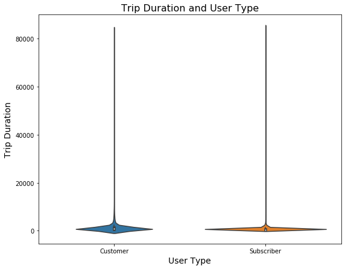

```python
# User Type and Duration
plt.rcParams['figure.figsize'] = 9, 7
sb.violinplot(data=df,x='user_type',y='duration_sec');
plt.xlabel('User Type', fontsize=14)
plt.ylabel('Trip Duration', fontsize=14)
plt.title("Trip Duration and User Type", fontsize=16);
```

### Trip Duration and Station

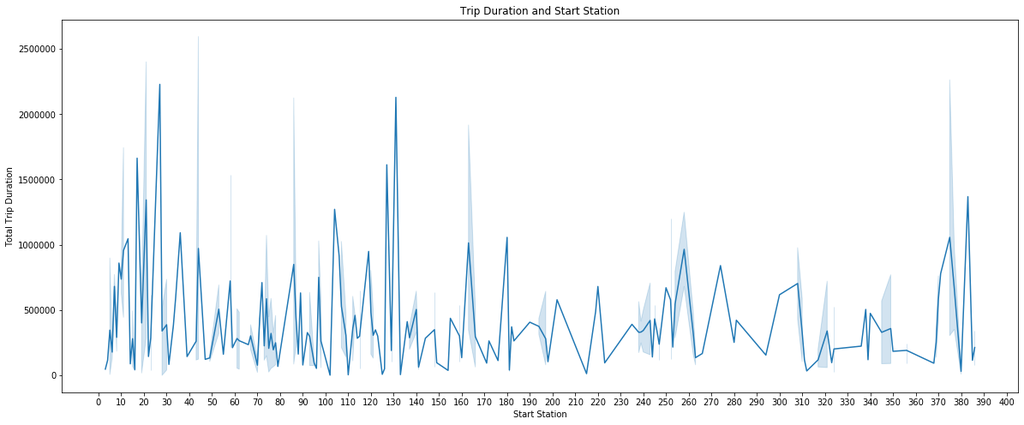

```python
Start = []

all_start_station_ids = sorted(df.start_station_id.unique())
for x in all_start_station_ids :
    Start.append(df[df.start_station_id == x].duration_sec.sum())
total_duration = pd.Series(Start)

plt.figure(figsize = [20, 8])
sb.lineplot(x = df['start_station_id'], y = total_duration)
plt.xticks(range(0, 401, 10))
plt.title('Trip Duration and Start Station')
plt.xlabel('Start Station')
plt.ylabel('Total Trip Duration')
plt.show()
```

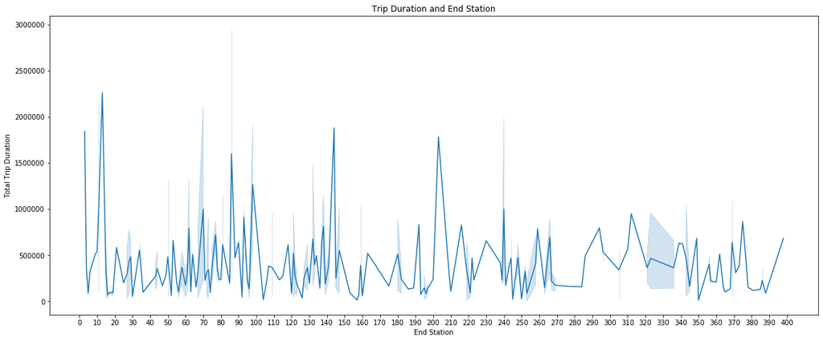

```python
End = []

all_end_station_ids = sorted(df.end_station_id.unique())
for x in all_end_station_ids :
    End.append(df[df.end_station_id == x].duration_sec.sum())
total_duration = pd.Series(End)

plt.figure(figsize = [20, 8])
sb.lineplot(x = df['end_station_id'], y = total_duration)
plt.xticks(range(0, 401, 10))
plt.title('Trip Duration and End Station')
plt.xlabel('End Station')
plt.ylabel('Total Trip Duration')
plt.show()
```

### Trip Duration, Bike Sharing and User Type

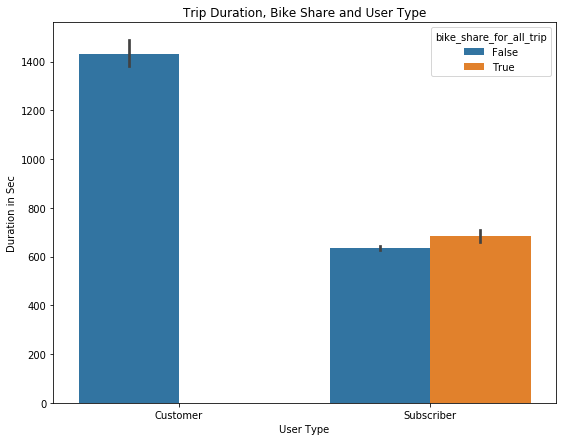

```python
sb.barplot(data=df, x='user_type',y='duration_sec',hue='bike_share_for_all_trip')
plt.title('Trip Duration, Bike Share and User Type')
plt.xlabel('User Type')
plt.ylabel('Duration in Sec')
plt.show()
```

Here, we can see that no customer had a bike share and they had the highest no of trips in duration compared with subscriber.